# Report

Author

291921

```r
library(tidyverse)
library(broom)
library(broom.mixed)
library(datawizard)
library(here)
library(interactions)
library(modelbased)
library(purrr)
library(kableExtra)
library(lme4)

# load the data

stats_tib <- here::here("data/tap_learning_statistics.csv") |>
  readr::read_csv() |>
  dplyr::mutate(
    uni = forcats::as_factor(uni) |>
      forcats::fct_relevel(paste("University", 1:20)),
    community = forcats::fct_relevel(community, "None", "Online", "In person"))

uni_lev <- levels(stats_tib$uni)
com_lev <- levels(stats_tib$community)
```

## **Analysis plan**

The model to be fitted is

$$\text{Performance}_{ij} = [\hat{b}_0 + \hat{b}_1\text{General Anxiety}_{ij} + \hat{b}_2\text{Statistics Anxiety}_{ij} + \hat{b}_3\text{Community}_{ij} + \hat{b}_4\text{Statistics Anxiety*Community}_{ij}] + [\hat{u}_{0j} + \hat{u}_{1j}\text{Statistics Anxiety} + e_{ij}]$$

There are several assumptions that need to be met for the general linear model. First, linearity of the model will be assumed, meaning that the relationship between the independent variables (statistics anxiety and community) and the dependent variable (performance) is linear. Second, the assumption of homoscedasticity of the residuals will be checked. This means that the variance of the residuals is constant across all values of the independent variables. This assumption will be evaluated using diagnostic plots to check whether the residuals have constant variance (homoscedasticity). Lastly, normality of the residuals will be assessed using a Q-Q plot to determine if the residuals closely follow a normal distribution, which would support the model’s assumption.

If the assumption (normality and homoscedasticity of residuals) is violated, robust regression methods will be explained to provide more reliable estimates.

Data will be summarized and visualized as follows :

- Visualize the existing data to examine the interactions between predictors. Specifically, investigate how community moderates the relationship between statistics anxiety and performance, and whether there are differences across universities.
- Summarize the standard deviations of each predictor by university to examine the variability of variables across hierarchical levels.
- Examine plots to assess the variability of each estimate for fixed effects and interaction effects.
- Plots to assess the assumptions of the general linear model, including linearity of the model and normality and homoscedasticity of residuals.

In addition, the interaction effect will be tested to determine if it is statistically significant. One variable (statistics anxiety) is continuous, and the other variable (community) is categorical. The outcome (performance) will be examined to assess whether the interaction between statistics anxiety and community influences performance, and whether the community moderates the relationship between statistics anxiety and performance.

Moreover, in the hierarchical model, random effects will be added to estimate the variability in intercepts and slopes across universities. Specifically, the model will analyze how the effect size of statistics anxiety differs by university. The standard deviations of the university-level intercepts and slopes will be interpreted to assess the degree of variability.

## Coding

### **Summary statistics and data visualization**

```r
# visualize the data
stats_gg <- ggplot2::ggplot(stats_tib, aes(stats_anxiety, stats_exam)) +
  geom_point(alpha = 0.5, size = 1, color = "#f46595") +
  geom_smooth(method = "lm", size = 0.5, color = "#b9cfac") +
  coord_cartesian(xlim = c(0, 70), ylim = c(0, 100)) +
  scale_y_continuous(breaks = seq(0, 100, 20)) +
  labs(x = "State of Statistics Anxiety", y = "Grade of Statistics Exam") +
  facet_wrap(~ uni, ncol = 4) +
  theme_minimal()

# summary of the data
stats_sum <- stats_tib|>
  dplyr::group_by(uni)|>
  datawizard::describe_distribution(
    select = c("gen_anxiety", "stats_anxiety","stats_exam",), ci = 0.95
  )
stats_sum <- stats_sum |>
  knitr::kable(digits=2)
```

### **Statistical models**

```r
# Fitting mixed effect models
pooled_lm <- lm(stats_exam ~ stats_anxiety*community + gen_anxiety,
                data = stats_tib)
pooled_lm_br <- broom::tidy(pooled_lm, conf.int = TRUE) |>
  knitr::kable(digits =2)

# Fit the model in each universities
stats_lms <- stats_tib|>
  dplyr::arrange(uni)|>
  dplyr::group_by(uni)|>
  tidyr::nest()|>
  dplyr::mutate(
    model = purrr::map(.x = data, .f = \(stats_tib) lm(stats_exam ~ stats_anxiety * community + gen_anxiety, data = stats_tib)),
    coefs = purrr::map(model, broom::tidy, conf.int = TRUE)
  )

models_tib <- stats_lms |>
  dplyr::select(-c(data, model)) |>
  tidyr::unnest(coefs)

# visualize the estimate
models_gg <- ggplot(models_tib, aes(estimate)) +
  geom_density() +
  facet_wrap(~term, scales = "free") +
  theme_minimal()

# Fitting multilevel models
stats_mod <- lmerTest::lmer(stats_exam ~ stats_anxiety*community
                            + gen_anxiety + (stats_anxiety|uni),
                            data = stats_tib)

# Interpreting the model
stats_anova <- anova(stats_mod) |>
  knitr::kable(digits = 2)

stats_br <- broom.mixed::tidy(stats_mod, conf.int = T) |>
  knitr::kable(digits = 2)

stats_slopes <- modelbased::estimate_slopes(stats_mod,
                                            trends = "stats_anxiety",
                                            at = "community")

stats_slopes <- stats_slopes |> knitr::kable(digits = 2)

stats_inter <- interactions::interact_plot(
  model = stats_mod,
  pred = stats_anxiety,
  modx = community,
  interval = TRUE,
  x.label = "Statistics Anxiety",
  y.label = "Performance",
  legend.main = "community"
)
```

### **Model assumptions**

```r
model_plot <- performance::check_model(stats_mod,
                                       check = c("linearity", "homogeneity",
                                                 "outliers", "qq", "reqq"))
```

### Robust model

```r
stats_rob <- robustlmm::rlmer(stats_exam ~ stats_anxiety*community + gen_anxiety + (stats_anxiety|uni), data = stats_tib)
```

## **Report**

### **Summary statistics and data visualization**

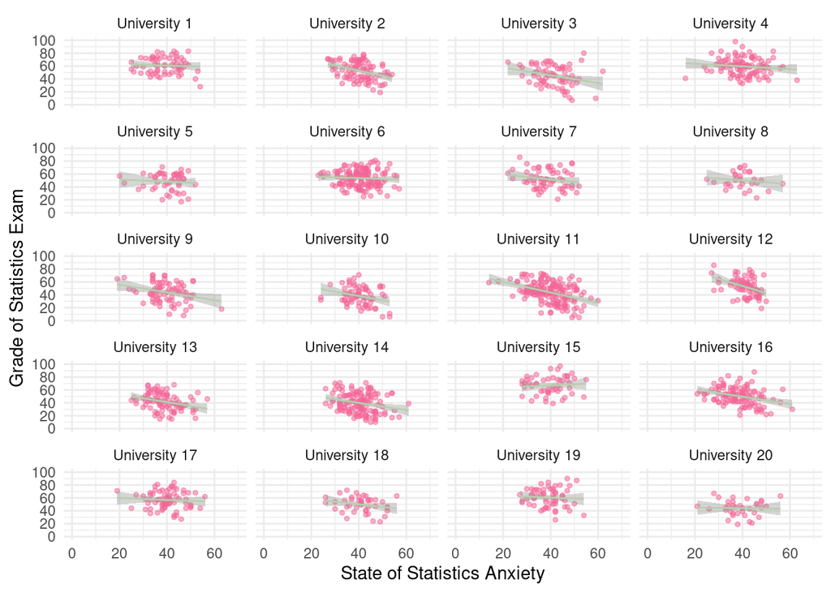

Figure 1: Plot of Statistics Performance as Universities

```r
stats_gg
```

Figure 1 shows the relationship between statistics anxiety and performance on the statistics exam for each university. Overall, higher statistics anxiety is associated with lower performance, as evident in the downward slope observed across most universities.

However, the strength of this relationship varies by university. For example, some universities (e.g., University 11 and University 12) show a steep negative slope, indicating a stronger association, while others (e.g., University 1 and University 5) show a flatter slope, suggesting a weaker relationship. This suggests that performance may vary not only due to statistical uncertainty and community factors but also depending on the university, indicating the need for multilevel analysis.

```r
stats_sum
```

Table 1: Statistics Summary as Universities

| Variable | Mean | SD | IQR | CI_low | CI_high | Min | Max | Skewness | Kurtosis | n | n_Missing | .group |
| --- | --- | --- | --- | --- | --- | --- | --- | --- | --- | --- | --- | --- |
| gen_anxiety | 40.03 | 7.14 | 9.00 | 38.28 | 41.71 | 23 | 56 | 0.05 | 0.01 | 64 | 0 | uni=University 1 |
| stats_anxiety | 39.34 | 6.90 | 10.75 | 38.07 | 41.06 | 25 | 54 | -0.11 | -0.53 | 64 | 0 | uni=University 1 |
| stats_exam | 60.84 | 12.21 | 20.75 | 56.99 | 63.69 | 28 | 83 | -0.13 | -0.51 | 64 | 0 | uni=University 1 |
| gen_anxiety | 40.42 | 6.91 | 8.00 | 39.36 | 41.72 | 27 | 65 | 0.70 | 1.24 | 91 | 0 | uni=University 2 |
| stats_anxiety | 40.34 | 6.31 | 7.00 | 39.14 | 41.61 | 27 | 54 | -0.07 | -0.32 | 91 | 0 | uni=University 2 |
| stats_exam | 52.55 | 14.14 | 24.00 | 49.46 | 55.23 | 19 | 78 | -0.16 | -0.97 | 91 | 0 | uni=University 2 |
| gen_anxiety | 39.31 | 7.89 | 12.00 | 37.64 | 41.08 | 21 | 57 | 0.29 | -0.38 | 70 | 0 | uni=University 3 |
| stats_anxiety | 41.39 | 7.46 | 10.00 | 39.75 | 42.67 | 22 | 62 | 0.07 | 0.31 | 70 | 0 | uni=University 3 |
| stats_exam | 44.86 | 16.30 | 23.50 | 40.02 | 48.26 | 7 | 80 | -0.27 | -0.52 | 70 | 0 | uni=University 3 |
| gen_anxiety | 40.75 | 6.36 | 7.25 | 39.60 | 42.01 | 29 | 61 | 0.78 | 0.75 | 102 | 0 | uni=University 4 |
| stats_anxiety | 40.50 | 7.58 | 9.00 | 39.06 | 41.84 | 16 | 63 | -0.08 | 0.78 | 102 | 0 | uni=University 4 |
| stats_exam | 59.39 | 13.08 | 19.00 | 56.89 | 62.09 | 33 | 98 | 0.24 | -0.17 | 102 | 0 | uni=University 4 |
| gen_anxiety | 40.41 | 7.44 | 13.50 | 38.49 | 42.62 | 22 | 54 | 0.03 | -0.51 | 49 | 0 | uni=University 5 |
| stats_anxiety | 40.27 | 6.65 | 8.50 | 38.88 | 42.25 | 20 | 52 | -1.05 | 1.35 | 49 | 0 | uni=University 5 |
| stats_exam | 48.10 | 13.59 | 21.50 | 44.08 | 51.17 | 17 | 71 | -0.63 | -0.55 | 49 | 0 | uni=University 5 |
| gen_anxiety | 40.02 | 6.50 | 9.00 | 39.12 | 41.11 | 25 | 57 | -0.01 | -0.49 | 137 | 0 | uni=University 6 |
| stats_anxiety | 40.60 | 6.76 | 9.00 | 39.33 | 41.67 | 23 | 57 | -0.10 | 0.00 | 137 | 0 | uni=University 6 |
| stats_exam | 53.64 | 12.95 | 21.00 | 51.41 | 55.73 | 25 | 81 | -0.06 | -0.80 | 137 | 0 | uni=University 6 |
| gen_anxiety | 39.66 | 5.17 | 7.00 | 38.56 | 40.99 | 28 | 54 | 0.41 | 0.37 | 62 | 0 | uni=University 7 |
| stats_anxiety | 38.56 | 7.01 | 10.25 | 36.29 | 40.41 | 22 | 52 | -0.15 | -0.44 | 62 | 0 | uni=University 7 |
| stats_exam | 52.00 | 14.64 | 23.50 | 49.71 | 55.36 | 21 | 86 | 0.18 | -0.75 | 62 | 0 | uni=University 7 |
| gen_anxiety | 38.59 | 7.45 | 10.50 | 35.76 | 40.79 | 23 | 51 | -0.04 | -0.73 | 29 | 0 | uni=University 8 |
| stats_anxiety | 39.97 | 6.53 | 7.00 | 37.77 | 42.01 | 25 | 57 | 0.18 | 1.15 | 29 | 0 | uni=University 8 |
| stats_exam | 50.14 | 12.79 | 18.50 | 46.00 | 54.28 | 23 | 73 | -0.06 | -0.56 | 29 | 0 | uni=University 8 |
| gen_anxiety | 40.11 | 7.43 | 8.75 | 38.61 | 41.53 | 21 | 60 | 0.11 | 0.50 | 76 | 0 | uni=University 9 |
| stats_anxiety | 39.67 | 7.32 | 10.00 | 37.91 | 41.46 | 19 | 63 | -0.05 | 1.12 | 76 | 0 | uni=University 9 |
| stats_exam | 44.07 | 15.24 | 24.75 | 40.33 | 47.49 | 8 | 71 | -0.22 | -0.57 | 76 | 0 | uni=University 9 |
| gen_anxiety | 40.29 | 7.32 | 10.00 | 38.60 | 41.92 | 23 | 55 | -0.26 | -0.25 | 69 | 0 | uni=University 10 |
| stats_anxiety | 40.25 | 5.95 | 7.50 | 38.95 | 41.55 | 24 | 53 | -0.17 | 0.60 | 69 | 0 | uni=University 10 |
| stats_exam | 38.14 | 14.43 | 21.50 | 35.10 | 41.94 | 6 | 71 | -0.07 | -0.41 | 69 | 0 | uni=University 10 |
| gen_anxiety | 38.98 | 7.22 | 10.00 | 37.86 | 40.06 | 20 | 60 | 0.05 | -0.08 | 162 | 0 | uni=University 11 |
| stats_anxiety | 39.83 | 7.67 | 10.00 | 38.65 | 40.95 | 14 | 60 | -0.25 | 0.27 | 162 | 0 | uni=University 11 |
| stats_exam | 43.77 | 15.61 | 21.25 | 41.59 | 45.83 | 5 | 73 | -0.29 | -0.45 | 162 | 0 | uni=University 11 |
| gen_anxiety | 40.08 | 6.96 | 10.25 | 38.38 | 41.66 | 26 | 61 | 0.51 | 0.06 | 72 | 0 | uni=University 12 |
| stats_anxiety | 41.11 | 5.14 | 6.75 | 39.90 | 42.37 | 27 | 50 | -0.87 | 0.65 | 72 | 0 | uni=University 12 |
| stats_exam | 52.53 | 14.23 | 20.50 | 49.47 | 56.08 | 19 | 86 | 0.01 | -0.54 | 72 | 0 | uni=University 12 |
| gen_anxiety | 39.57 | 6.78 | 11.00 | 38.12 | 40.92 | 23 | 55 | -0.22 | -0.56 | 88 | 0 | uni=University 13 |
| stats_anxiety | 38.81 | 6.58 | 8.75 | 37.30 | 40.49 | 25 | 57 | 0.42 | -0.02 | 88 | 0 | uni=University 13 |
| stats_exam | 41.80 | 13.19 | 19.75 | 38.58 | 45.27 | 15 | 68 | -0.03 | -0.64 | 88 | 0 | uni=University 13 |
| gen_anxiety | 40.84 | 7.70 | 11.00 | 39.70 | 42.44 | 24 | 59 | 0.14 | -0.51 | 130 | 0 | uni=University 14 |
| stats_anxiety | 40.41 | 6.65 | 9.00 | 39.35 | 41.43 | 26 | 61 | 0.26 | 0.12 | 130 | 0 | uni=University 14 |
| stats_exam | 39.69 | 15.20 | 25.00 | 37.63 | 42.14 | 10 | 71 | 0.09 | -0.92 | 130 | 0 | uni=University 14 |
| gen_anxiety | 38.54 | 6.44 | 8.75 | 37.35 | 40.24 | 26 | 54 | 0.44 | -0.12 | 52 | 0 | uni=University 15 |
| stats_anxiety | 39.85 | 7.01 | 11.00 | 37.57 | 41.72 | 28 | 55 | -0.02 | -0.74 | 52 | 0 | uni=University 15 |
| stats_exam | 67.17 | 13.94 | 18.75 | 62.53 | 70.17 | 39 | 97 | -0.10 | -0.59 | 52 | 0 | uni=University 15 |
| gen_anxiety | 39.38 | 6.56 | 8.25 | 38.28 | 40.37 | 19 | 59 | -0.27 | 0.65 | 114 | 0 | uni=University 16 |
| stats_anxiety | 38.45 | 7.57 | 10.00 | 36.88 | 40.24 | 21 | 61 | 0.17 | 0.14 | 114 | 0 | uni=University 16 |
| stats_exam | 50.39 | 13.28 | 17.25 | 48.27 | 52.70 | 21 | 88 | 0.06 | -0.05 | 114 | 0 | uni=University 16 |
| gen_anxiety | 39.88 | 7.40 | 9.00 | 38.60 | 41.46 | 21 | 57 | -0.05 | -0.12 | 72 | 0 | uni=University 17 |
| stats_anxiety | 39.93 | 6.60 | 7.75 | 38.43 | 41.62 | 19 | 56 | -0.23 | 0.89 | 72 | 0 | uni=University 17 |
| stats_exam | 56.85 | 13.12 | 19.50 | 53.66 | 59.08 | 27 | 84 | -0.11 | -0.57 | 72 | 0 | uni=University 17 |
| gen_anxiety | 38.69 | 7.28 | 10.25 | 36.65 | 40.83 | 26 | 55 | 0.00 | -0.50 | 42 | 0 | uni=University 18 |
| stats_anxiety | 41.02 | 7.10 | 9.50 | 38.69 | 42.88 | 26 | 56 | -0.12 | -0.26 | 42 | 0 | uni=University 18 |
| stats_exam | 49.74 | 12.06 | 16.50 | 46.08 | 52.84 | 23 | 72 | -0.42 | -0.39 | 42 | 0 | uni=University 18 |
| gen_anxiety | 37.93 | 7.96 | 12.75 | 35.77 | 39.77 | 24 | 57 | 0.27 | -0.59 | 60 | 0 | uni=University 19 |
| stats_anxiety | 39.27 | 6.09 | 7.75 | 37.55 | 40.65 | 27 | 54 | 0.06 | -0.42 | 60 | 0 | uni=University 19 |
| stats_exam | 60.68 | 14.18 | 21.75 | 57.09 | 63.88 | 26 | 90 | -0.15 | -0.49 | 60 | 0 | uni=University 19 |
| gen_anxiety | 41.03 | 5.59 | 9.00 | 39.19 | 42.81 | 26 | 52 | -0.49 | 0.36 | 35 | 0 | uni=University 20 |
| stats_anxiety | 39.06 | 7.34 | 11.00 | 37.04 | 41.99 | 21 | 56 | -0.10 | 0.21 | 35 | 0 | uni=University 20 |
| stats_exam | 44.17 | 12.04 | 18.00 | 40.60 | 47.94 | 19 | 67 | -0.28 | -0.33 | 35 | 0 | uni=University 20 |

In summary, significant variability in performance and its relationship with statistics anxiety across universities justifies the need for multilevel modeling to account for these hierarchical data structures.

### Model assumption

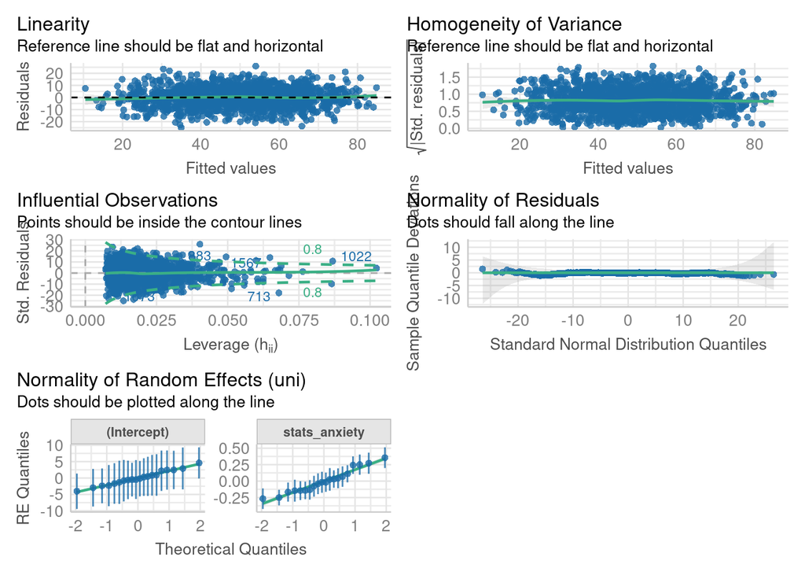

Figure 2: Plot for diagnostic

```r
model_plot
```

### Statistical models

```r
pooled_lm_br
```

Table 2: Statistics estimated of pooled model

| term | estimate | std.error | statistic | p.value | conf.low | conf.high |
| --- | --- | --- | --- | --- | --- | --- |
| (Intercept) | 53.29 | 3.15 | 16.94 | 0.00 | 47.12 | 59.47 |
| stats_anxiety | -0.70 | 0.07 | -10.44 | 0.00 | -0.83 | -0.57 |
| communityOnline | 5.57 | 3.85 | 1.45 | 0.15 | -1.97 | 13.12 |
| communityIn person | 3.01 | 3.94 | 0.76 | 0.44 | -4.71 | 10.73 |
| gen_anxiety | 0.29 | 0.04 | 7.56 | 0.00 | 0.22 | 0.37 |
| stats_anxiety:communityOnline | 0.18 | 0.09 | 1.95 | 0.05 | 0.00 | 0.37 |
| stats_anxiety:communityIn person | 0.59 | 0.10 | 6.04 | 0.00 | 0.40 | 0.78 |

Table 2 shows that performance is predicted by each variable. This is to confirm the overall main effect and interaction effects of the model, serving as a preliminary process for conducting multilevel analysis. The baseline performance is $\hat{b} = 53.29 [47.12, 59.47], t = 16.94, p < 0.001.$ This value is significant cause the confidence interval does not include 0. Also, the baseline score is relatively high, indicating that students’ statistics exam scores are quite good when unaffected by other variables.

Both statistics anxiety and general anxiety significantly predict performance. Specifically, as students experienced higher levels of statistics anxiety, their exam performance tended to decrease $\hat{b} = -0.70 [-0.83, -0.57], t = -10.44, p < 0.001.$ For every one-unit increase in statistics anxiety, performance decreased by 0.70 units. The confidence interval does not include 0, indicating that this main effect is significant. Although the value (-0.70) may appear small, given that performance scores range from 0 to 100, it represents a meaningful difference in the academic environment.

In contrast, students with higher general anxiety tended to perform better on their exams $\hat{b} = 0.29 [0.22, 0.37], t = 7.56, p < 0.001.$ For every one-unit increase in general anxiety, performance increased by 0.29 units. The confidence interval does not include 0, indicating that this main effect is significant. Although the effect size (0.29) is smaller than that of statistics anxiety, it suggests a positive relationship with performance. This result implies that general anxiety might serve as a source of motivation for improved performance.

However, the main effects of community type (Online and In-person) were not significant predictors of performance $\hat{b} = 5.57 [-1.97, 13.12], t = 1.45, p = 0.15$ for online, $\hat{b} = 3.01 [-4.71, 10.73], t = 0.76, p = 0.44$ for in-person. The confidence intervals for both effects include 0, indicating that community type alone does not significantly predict performance.

The effects of statistics anxiety on exam performance varied by community type. Specifically, the interaction between statistics anxiety and the online community was not significant $\hat{b} = 0.18 [0.00, 0.37], t = 1.95, p = 0.05.$ For every one-unit increase in the interaction, performance increased by 0.18 units. However, the confidence interval includes 0, indicating that this interaction effect is not significant.

On the other hand, students in the in-person community showed improved performance $\hat{b} = 0.59 [0.40, 0.78], t = 6.04, p < 0.001.$ For every one-unit increase in the interaction, performance increased by 0.59 units. The confidence interval does not include 0, indicating that this interaction effect is significant. Given the performance range of 0 to 100, this value (0.59) represents a meaningful difference in the academic environment.

This result suggests that the in-person community mitigates the negative relationship between statistics anxiety and performance. In short, students in the in-person community experienced less statistics anxiety, which ultimately improved their performance.

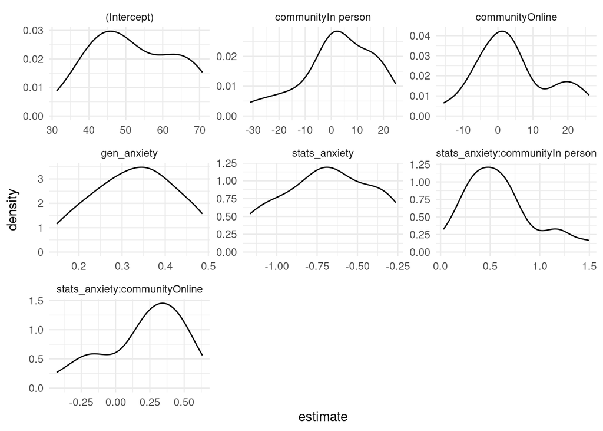

Figure 3: Plot of estimates as universities

```r
models_gg
```

Figure 3 shows the distributions of parameter estimates across the 20 universities. The intercept is centered around 40 to 50, with the majority of the distribution falling between 35 and 70. This indicates considerable variability in performance across universities, and as such, the intercept is treated as a random effect.

General anxiety estimates range from approximately 0.3 to 0.4, with most of the distribution falling between 0.2 and 0.4. Although this value appears small, considering the performance scores range from 0 to 100, it could still play a crucial role in academic performance.

Statistics anxiety estimates are centered around -0.75, with most of the distribution falling between -1.00 and -0.50. While these values may also seem small, in the context of a 0 to 100 performance score range, they could represent significant effects.

Furthermore, statistics anxiety shows substantial variability across universities, supporting its treatment as a random effect. In summary, statistics anxiety varies significantly across universities, contributing to differences in performance outcomes.

```r
stats_anova
```

Table 3: Statistics for anova of model

|  | Sum Sq | Mean Sq | NumDF | DenDF | F value | Pr(>F) |
| --- | --- | --- | --- | --- | --- | --- |
| stats_anxiety | 3916.94 | 3916.94 | 1 | 20.22 | 64.03 | 0.00 |
| community | 150.99 | 75.49 | 2 | 1535.00 | 1.23 | 0.29 |
| gen_anxiety | 7612.61 | 7612.61 | 1 | 1548.02 | 124.44 | 0.00 |
| stats_anxiety:community | 3927.46 | 1963.73 | 2 | 1537.73 | 32.10 | 0.00 |

There are significant main effects of both statistics anxiety and general anxiety, $F(1, 20.22) = 64.03, p < 0.001, F(1, 1548.02) = 124.44, p < 0.001$ and the interaction (statistics anxiety * community), $F(2, 1537.73) = 32.10, p < 0.001.$ But community is not significant, $F(2, 1535.00) = 1.23, p = 0.29.$ (Table 3)

This results suggest that both kinds of anxiety (statistic and general) and interaction between statistics and community influence on performance.

```r
stats_br
```

Table 4: Statistics of fixed and random effect

| effect | group | term | estimate | std.error | statistic | df | p.value | conf.low | conf.high |
| --- | --- | --- | --- | --- | --- | --- | --- | --- | --- |
| fixed | NA | (Intercept) | 52.20 | 2.47 | 21.11 | 157.45 | 0.00 | 47.32 | 57.09 |
| fixed | NA | stats_anxiety | -0.68 | 0.07 | -10.31 | 49.78 | 0.00 | -0.81 | -0.55 |
| fixed | NA | communityOnline | 4.04 | 2.82 | 1.43 | 1540.30 | 0.15 | -1.50 | 9.58 |
| fixed | NA | communityIn person | 3.65 | 2.89 | 1.26 | 1545.25 | 0.21 | -2.01 | 9.31 |
| fixed | NA | gen_anxiety | 0.32 | 0.03 | 11.16 | 1548.02 | 0.00 | 0.26 | 0.37 |
| fixed | NA | stats_anxiety:communityOnline | 0.21 | 0.07 | 3.07 | 1541.78 | 0.00 | 0.08 | 0.35 |
| fixed | NA | stats_anxiety:communityIn person | 0.57 | 0.07 | 7.96 | 1545.79 | 0.00 | 0.43 | 0.71 |
| ran_pars | uni | sd__(Intercept) | 3.72 | NA | NA | NA | NA | NA | NA |
| ran_pars | uni | cor__(Intercept).stats_anxiety | -0.23 | NA | NA | NA | NA | NA | NA |
| ran_pars | uni | sd__stats_anxiety | 0.19 | NA | NA | NA | NA | NA | NA |
| ran_pars | Residual | sd__Observation | 7.82 | NA | NA | NA | NA | NA | NA |

Table 4 shows the fixed effect and the random effect as universities. The fixed effects show the average effects of variables adjusted commonly to all levels (universities). The estimate of intercept is baseline of performance, $\beta = 52.20 [47.32, 57.09], t = 21.11, p < 0.001.$ The confidence interval does not include 0, indicating that this main effect is significant. This value is relatively high, indicating that students’ statistics exam scores are quite good when unaffected by other variables.

The effects of statistics anxiety is significant, $\beta = -0.68 [-0.81, -0.55], t = -10.31, p < 0.001.$ For every one-unit increase in statistics anxiety, performance decreased by 0.68 units. The confidence interval does not include 0, indicating that this main effect is significant. This suggests that statistics anxiety predicts negatively performance. In short, the students who feel more statistics anxious have less performance in exam. This value is not small cause given score on performance is 0 to 100 in academic environment.

However, general anxiety predicts positively performance, $\beta = 0.32 [0.26, 0.37], t = 11.16, p < 0.001.$ Specifically, for every one-unit increase in general anxiety, performance increased by 0.32 units. The confidence interval does not include 0, indicating that this main effect is significant. This suggests that performance is motivated by general anxiety. This value is also significant in academic environment.

On the other hand, the overall effect of community (Online and In-person) on performance is non-significant, $\beta = 4.04 [-1.50, 9.58], t = 1.43, p = 0.15, \beta = 3.65 [-2.01, 9.31], t = 1.26, p = 0.21.$ This indicates that only community cannot influence on performance.

While the fixed effects provide insights into the overall patterns, the random effects highlight variability at the university level, reflecting the contextual differences across institutions. The estimate of standard deviation of intercepts was $\hat\sigma_{u0} = 3.72 [\text{NA, NA}],$ indicating difference of performance between universities. Notably, this value is considered a large number, indicating substantial variability in statistics scores across universities.

The standard deviation of observation was $\sigma = 7.82 [\text{NA, NA}].$ It is the unexpected volatility of individuals’ performance. This value seems quite huge, it is possible to have another factor to impact on individuals’ performance.

```r
stats_slopes
```

Table 5: Statistics of estimated slopes

| community | Coefficient | SE | CI | CI_low | CI_high | t | df_error | p |
| --- | --- | --- | --- | --- | --- | --- | --- | --- |
| None | -0.68 | 0.07 | 0.95 | -0.81 | -0.55 | -10.25 | 45.15 | 0.0 |
| Online | -0.47 | 0.07 | 0.95 | -0.60 | -0.33 | -6.99 | 45.18 | 0.0 |
| In person | -0.11 | 0.07 | 0.95 | -0.25 | 0.02 | -1.67 | 49.27 | 0.1 |

Table 5 shows estimates slopes of university as community separately. In none community, statistics anxiety is to be weaken performance, $\beta = -0.68 [-0.81, -0.55], t = -10.25, p < 0.001.$ But the effect of online community on performance make more weak, $\beta = -0.47 [-0.60, -0.33], t = -6.99, p < 0.001.$

In summary, the in-person community appears to be a strong moderating predictor in the relationship between statistics anxiety and performance, significantly weakening its negative impact. The findings underscore the importance of in-person interaction in alleviating the adverse effects of statistics anxiety.

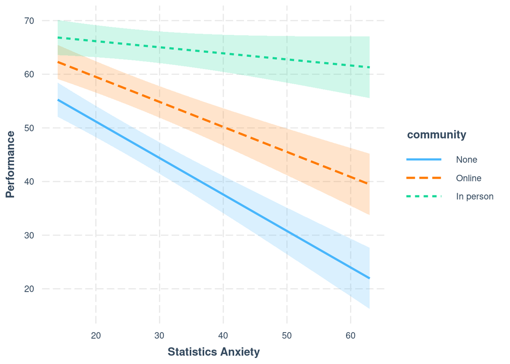

Figure 4: Plot for slopes as community

```r
stats_inter
```

Figure 4 shows different slopes of communities on performance. The none community has the steepest slope compared to the online and in-person communities. This indicates that the in-person community is the strongest moderating predictor of the relationship between statistics anxiety and performance. In summary, lower performance is predicted by higher statistics anxiety, but the impact of statistics anxiety on exam scores is mitigated in the in-person community.

## Summary

To sum up, hypothesis was supported. Performance on the statistics assignment was predicted by statistics anxiety. However, community was moderated the relationship between performance and statistics anxiety.

Specifically, the relationship between statistics anxiety and performance was weaker in those assigned to a peer community (online or in person) compared to those not. In addition, the effect which assigned to the in-person community was stronger than those assigned to the online community. In short, peer community was a protective factor that statistics anxiety affect negatively performance in statistics exam. Among them, the in-person community moderated the effect the most effectively.

In addition, the random effects analysis revealed significant variability in performance across universities. The random intercepts indicate substantial differences in baseline performance between universities, suggesting that institutional factors, such as academic support systems or teaching quality, may contribute to these differences.

Similarly, the random slopes for statistics anxiety suggest that the effect of statistics anxiety on performance varies across universities. Some universities may be more effective at buffering the negative effects of anxiety.